# Writing Faster R code

J. Piaskowski

This workshop/lesson provides some general hints and tips for writing code that runs faster and uses less memory. Writing more efficient code can involve:

1. utilizing base functioned that are parallelized
2. avoiding object types and operations which are slow and use extensive memory
3. reducing internal checks done by R
4. using specialized libraries for big tasks and big objects

#### The Process for Improving Code:

(quote from *Advanced R*)

> 1. Find the biggest bottleneck (the slowest part of your code).
> 2. Try to eliminate it (you may not succeed but that’s ok).
> 3. Repeat until your code is “fast enough.”

##### Easy peasy, right???

[figure not shown]

##### Vectorised functions:

- the apply family:
  - `apply()`
  - `lapply()`
  - `sapply()`
  - `vapply()`
  - `tapply()`
  - `mapply()`
- other common operation that work across columns and means:
  - `rowSums()`
  - `colSums()`
  - `rowMeans()`
  - `colMeans()`
  - `cumsum()`
  - `diff()`

##### Common R structures and functions to avoid:

- Use data frames less - they are expensive to create, often copied in whole when modified, and their rownames attribute can really slow things down.
- Be wary of using functions that copy objects in whole: `c()`, `append()`, `cbind()`, `rbind()`, and `paste().` When used in loops, you can get a massive proliferation of objects in memory.

##### some internal checks to avoid

- Base functions are designed to handle wildly different input. Consider rewriting base functions for highly repetitive tasks.
- `read.csv()`: specify known column types with `colClasses = c(...)`.

```
mydata <- read.csv("myfile.csv", colClasses = c("numeric","Date", "character", "factor","integer"))
```

- `factor()`: specify known levels with levels.

```
X <- factor(x, levels = c("factor1", "factor2", "factor4"))
```

- `cut()`: don’t generate labels with labels = FALSE if you don’t need them, or, even better, use `findInterval()`.

```r
x <- 1:15
cut(x, labels = F, breaks = 4)
```

```
##  [1] 1 1 1 1 2 2 2 2 3 3 3 4 4 4 4
```

```r
findInterval(x, c(0, 3, 7, 10))
```

```
##  [1] 1 1 2 2 2 2 3 3 3 4 4 4 4 4 4
```

- `unlist(x, use.names = FALSE)` is much faster than `unlist(x)`.
- `interaction()`: if you only need combinations that exist in the data, use `drop = TRUE`.

[figure not shown]

### Benchmarking!

> “I don’t even know you, but your intuition stinks.” -Joe Peng, RStudio CTO

The first step is always to check your code with benchmarking!!! Don’t assume you *know* where the bottlenecks in code execution occur.

**Important:** do not attempt to reinstall ‘compiler’ It is already installed and will cause problems if you try to override the default compiler configuration. In most systems, this package can be loaded through a standard `library()` call.

```r
pck <- c("compiler","microbenchmark", "profvis", "pryr")
invisible(lapply(pck, library, character.only = T))
```

First, Turn off the just-in-time compiler. Note that return value is what the JIT was set at previously (default = 3).

```r
enableJIT(0)
```

```
## [1] 3
```

#### The microbenchmark function

*for evaluating small snippets of code*

**Create data:**

```r
a <- function() {
  m <- sample(1:100, 4)
  data.x <- lapply(m, function(x) rnorm(1e4, mean = x))
  do.call("cbind", data.x)
}

some_data <- a()
head(some_data)
```

```
##          [,1]     [,2]     [,3]     [,4]
## [1,] 15.43356 80.95519 71.55570 88.40483
## [2,] 13.51488 81.31081 74.48272 88.80243
## [3,] 13.98222 82.44112 71.42563 88.77004
## [4,] 15.03497 81.51549 70.32690 87.69023
## [5,] 12.36781 82.19377 72.19266 88.43075
## [6,] 14.02306 82.67576 72.96822 87.07751
```

```r
dim(some_data)
```

```
## [1] 10000     4
```

**Compare calculation of column means with microbenchmarking:**

```r
microbenchmark(
  mean_vec = colMeans(some_data),
  mean_loop = apply(some_data, 2, mean),
  mean_manual = apply(some_data, 2, function(x) sum(x)/length(x)),
  mean_manual_ultra = apply(some_data, 2, function(x){
    total = 0
    n = 0
    i = 1
    while(!is.na(x[i])) {
      total = total + x[i]
      n = n+1
      i = i+1
    }
    total/n
  })
)
```

```
## Unit: microseconds
##               expr       min         lq       mean     median         uq
##           mean_vec    36.739    39.6535    53.5162    48.1165    53.3705
##          mean_loop   312.554   339.6590   436.5082   361.8210   499.5710
##        mean_manual   279.629   290.4600   368.5264   314.3035   438.6390
##  mean_manual_ultra 33086.358 33922.0195 35207.7276 34526.7615 35454.2645
##        max neval cld
##    494.188   100  a
##    901.969   100  a
##    723.029   100  a
##  56002.586   100   b
```

##### Prevent multiple dispatch:

Many function calls have multiple dispatch. R must figure out which version of a function to call depending on the input data.

```r
# example with the function mean()
methods(mean) # see different versions of mean
```

```
##  [1] mean,ANY-method          mean,Matrix-method
##  [3] mean,sparseMatrix-method mean,sparseVector-method
##  [5] mean.Date                mean.default
##  [7] mean.difftime            mean.POSIXct
##  [9] mean.POSIXlt             mean.yearmon*
## [11] mean.yearqtr*            mean.zoo*
## see '?methods' for accessing help and source code
```

```r
getAnywhere("mean") # to find out what packages have versions of the function "mean" in their namespace
```

```
## 2 differing objects matching 'mean' were found
## in the following places
##   package:base
##   namespace:base
##   namespace:Matrix
## Use [] to view one of them
```

```r
base:::mean.default # source code for the function
```

```
## function (x, trim = 0, na.rm = FALSE, ...)
## {
##     if (!is.numeric(x) && !is.complex(x) && !is.logical(x)) {
##         warning("argument is not numeric or logical: returning NA")
##         return(NA_real_)
##     }
##     if (na.rm)
##         x <- x[!is.na(x)]
##     if (!is.numeric(trim) || length(trim) != 1L)
##         stop("'trim' must be numeric of length one")
##     n <- length(x)
##     if (trim > 0 && n) {
##         if (is.complex(x))
##             stop("trimmed means are not defined for complex data")
##         if (anyNA(x))
##             return(NA_real_)
##         if (trim >= 0.5)
##             return(stats::median(x, na.rm = FALSE))
##         lo <- floor(n * trim) + 1
##         hi <- n + 1 - lo
##         x <- sort.int(x, partial = unique(c(lo, hi)))[lo:hi]
##     }
##     .Internal(mean(x))
## }
## <bytecode: 0x7fb7df0eb200>
## <environment: namespace:base>
```

**Compare different calls for mean:**

```r
x1 <- list(e2 = runif(1e2), e4 = runif(1e4), e6 = runif(1e6))

lapply(x1, function(x)
  microbenchmark(
    mean(x),
    mean.default(x)
  )
)
```

```
## $e2
## Unit: nanoseconds
##             expr  min     lq    mean median     uq   max neval cld
##          mean(x) 1956 2030.5 2748.29 2102.5 2194.5 24402   100   b
##  mean.default(x)  864  908.5  974.01  948.5  983.5  2910   100  a
##
## $e4
## Unit: microseconds
##             expr    min      lq     mean median     uq    max neval cld
##          mean(x) 17.746 17.8010 18.55054 17.840 17.907 45.131   100   a
##  mean.default(x) 16.573 16.6215 17.53360 16.664 16.752 46.575   100   a
##
## $e6
## Unit: milliseconds
##             expr      min       lq     mean   median       uq      max
##          mean(x) 1.639492 1.701499 1.815113 1.772777 1.874344 2.561929
##  mean.default(x) 1.638212 1.690663 1.786321 1.727252 1.812991 2.768500
##  neval cld
##    100   a
##    100   a
```

I suspect the improvement in speed for calling `mean.default()` for smaller objects occurs becauses R does not have to spend time evaluating which method to call like when using `mean()`. This effect is dwarfed when calling `mean()` for larger objects because the total amount of time needed to run the function is longer.

**What else could we do to speed up calls to** `mean()`**?**

### Code profiling

#### Find the bottlenecks with `Rprof()`

- Rprof writes stack calls to disk along with memory usage and vector duplication
- you create a .prof file to do this and then close it when done with profiling

**Data set up:**

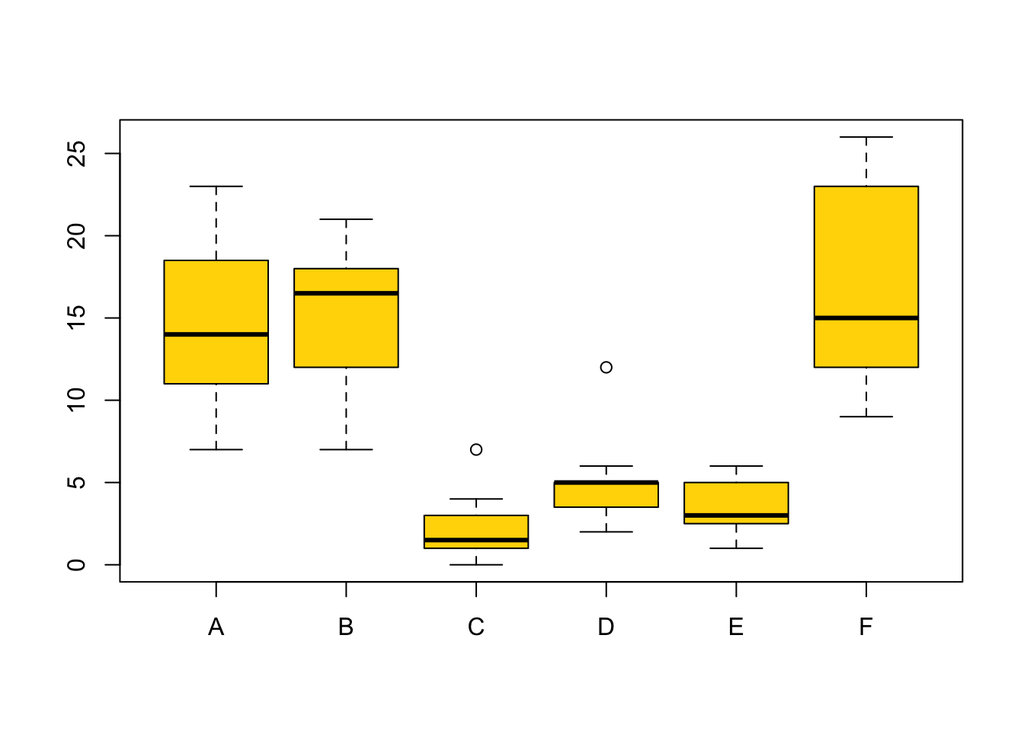

```r
data(InsectSprays)
boxplot(count ~ spray, data = InsectSprays, col = "gold")
```

```r
glm_func <- function(d) {
  glm.total = glm(count ~ spray, data = d,
                family = poisson(link = log))
  # extract means
  ls.raw = c(coef(glm.total)[1],
                     coef(glm.total)[2:6] + coef(glm.total)[1])
  names(ls.raw)[1] = "sprayA"
  list(exp(ls.raw))
}

glm_func(InsectSprays)
```

```
## [[1]]
##    sprayA    sprayB    sprayC    sprayD    sprayE    sprayF
## 14.500000 15.333333  2.083333  4.916667  3.500000 16.666667
```

**Profiling a permutation**

This can run very slow in RStudio.

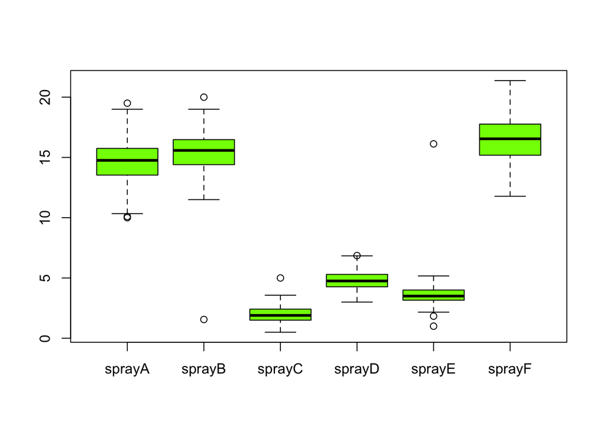

```r
Rprof("permute.prof", interval = 0.001) # set an interval appropriate for your system

glm_perm_func <- function() {
  # sample data set
  index <- sample(1:nrow(InsectSprays), 50, replace = T)
  insect <- InsectSprays[index,]
  # run model
  glm_func(insect)
}

many.perms <- replicate(100, glm_perm_func())

final <- do.call("rbind", many.perms)

boxplot(final, col = "chartreuse")
```

```r
Rprof(NULL)

sum_prof <- summaryRprof("permute.prof")
# best viewed in console, not RStudio
# "by.self"" time spent in function alone - more clearer, use this
# by.total is time spent in that function and the function below it

file.show("permute.prof")
# list of all function calls made (based on interval above)
```

#### Use `profvis()` to visualise performance

- nice graphical output
- native in RStudio (lots of [documentation](https://support.rstudio.com/hc/en-us/articles/218221837-Profiling-with-RStudio))

```r
p <- profvis({
  mean_loop = apply(some_data, 2, mean)
  mean_vec = colMeans(some_data)
  mean_manual = apply(some_data, 2, function(x) sum(x)/length(x))
  mean_manual_ultra = apply(some_data, 2, function(x){
    total = 0
    n = 0
    i = 1
    while(!is.na(x[i])) {
      total = total + x[i]
      n = n+1
      i = i+1
    }
    total/n
  })
})
htmlwidgets::saveWidget(p, "profile.html")

# Can open in browser from R
browseURL("profile.html")
```

### How to find function source code

(if you didn’t write the function yourself)

1. Type the function name (without parentheses) in the R console: `eigen`
2. Find namespace for a function (that is, it’s package hom) and additional methods associated with that function call:

```
`methods("princomp")
getAnywhere("princomp.default")`
```

1. Use the package **pryr** to search for C code on GitHub

.Internal and Primitive functions are written in C, so they cannot be accessed directly. You can try searching GitHub for C source code with `show_c_source()`.

```r
# source code for svd indicates it calls another function La.svd, which does much of th heavy lifting
svd
La.svd

try(show_c_source(.Internal(La_svd(x))))
show_c_source(.Internal(mean(x)))
```

#### More tips for finding source code

```r
otype(mean) # to determine object type (base, S3, S4, etc)
```

```
## [1] "base"
```

```r
ftype(mean) # provides more details on type of object
```

```
## [1] "s3"      "generic"
```

```r
methods(mean) # to find methods associated with a function call or class
```

```
##  [1] mean,ANY-method          mean,Matrix-method
##  [3] mean,sparseMatrix-method mean,sparseVector-method
##  [5] mean.Date                mean.default
##  [7] mean.difftime            mean.POSIXct
##  [9] mean.POSIXlt             mean.yearmon*
## [11] mean.yearqtr*            mean.zoo*
## see '?methods' for accessing help and source code
```

```r
methods(class = "lm") # for an entire class of objects
```

```
##  [1] add1           alias          anova          case.names
##  [5] coerce         confint        cooks.distance deviance
##  [9] dfbeta         dfbetas        drop1          dummy.coef
## [13] effects        extractAIC     family         formula
## [17] hatvalues      influence      initialize     kappa
## [21] labels         logLik         model.frame    model.matrix
## [25] nobs           plot           predict        print
## [29] proj           qr             residuals      rstandard
## [33] rstudent       show           simulate       slotsFromS3
## [37] summary        variable.names vcov
## see '?methods' for accessing help and source code
```

```r
# shows methods for other object types, often S4
#showMethods("%*%") # too much output to actually run
#showMethods(class = "Matrix") # like methods, but for S4 generic methods

# other option when methods() and showMethods() does not work:

getAnywhere(var)
```

```
## A single object matching 'var' was found
## It was found in the following places
##   package:stats
##   namespace:stats
## with value
##
## function (x, y = NULL, na.rm = FALSE, use)
## {
##     if (missing(use))
##         use <- if (na.rm)
##             "na.or.complete"
##         else "everything"
##     na.method <- pmatch(use, c("all.obs", "complete.obs", "pairwise.complete.obs",
##         "everything", "na.or.complete"))
##     if (is.na(na.method))
##         stop("invalid 'use' argument")
##     if (is.data.frame(x))
##         x <- as.matrix(x)
##     else stopifnot(is.atomic(x))
##     if (is.data.frame(y))
##         y <- as.matrix(y)
##     else stopifnot(is.atomic(y))
##     .Call(C_cov, x, y, na.method, FALSE)
## }
## <bytecode: 0x7fb7e159c2b8>
## <environment: namespace:stats>
```

#### Other options for obtaining source code

- Download the source code directly from CRAN:

```r
download.packages("qtl", repos = "https://cloud.r-project.org", destdir = getwd(), type = "source")
```

```
##      [,1]
## [1,] "qtl"
##      [,2]
## [1,] "/Users/juliapiaskowski/Sync/Teaching/code profiling/qtl_1.44-9.tar.gz"
```

- Download source code directly from its repository on GitHub, GitLab, Bitbucket, etc. This is often the only option for packages not on CRAN. For packages currently on CRAN or bioconductor, online version control repositories often contain the most current developments in the software, prior to their push to CRAN. Use `download.file()` to download a file from the internet.

#### Track when objects are copied

The function `tracemem()` can be used to track particular objects are copied in memory. It will let us know evertime an object is copied

```r
# simple example
a <- letters[sample(10)]
tracemem(a)
```

```
## [1] "<0x7fb7e550d618>"
```

```r
a[1] <- "Z" # a copied
```

```
## tracemem[0x7fb7e550d618 -> 0x7fb7e550e698]: eval eval withVisible withCallingHandlers handle timing_fn evaluate_call <Anonymous> evaluate in_dir block_exec call_block process_group.block process_group withCallingHandlers process_file <Anonymous> <Anonymous>
```

```r
b <- a
tracemem(b) # b and a share memory
```

```
## [1] "<0x7fb7e550e698>"
```

```r
# bigger examples
cat("\nx_vec\n")
```

```
##
## x_vec
```

```r
x_vec <- 1:10
tracemem(x_vec)
```

```
## [1] "<0x7fb7e16f2708>"
```

```r
for(i in 1:length(x_vec)){ #copied
  x_vec[i] = x_vec[i]^2
} #copied 2x
```

```
## tracemem[0x7fb7e16f2708 -> 0x7fb7e565c2e8]: eval eval withVisible withCallingHandlers handle timing_fn evaluate_call <Anonymous> evaluate in_dir block_exec call_block process_group.block process_group withCallingHandlers process_file <Anonymous> <Anonymous>
## tracemem[0x7fb7e565c2e8 -> 0x7fb7e544d5b8]: eval eval withVisible withCallingHandlers handle timing_fn evaluate_call <Anonymous> evaluate in_dir block_exec call_block process_group.block process_group withCallingHandlers process_file <Anonymous> <Anonymous>
```

```r
x_vec <- x_vec^2 # not copied

# a list
cat("\nx_list\n")
```

```
##
## x_list
```

```r
x_list <- as.list(1:10)
tracemem(x_list)
```

```
## [1] "<0x7fb7e83faf78>"
```

```r
for(i in 1:length(x_list)){
  x_list[[i]] = x_list[[i]]^2
} #copied 1x
```

```
## tracemem[0x7fb7e83faf78 -> 0x7fb7e83fc628]: eval eval withVisible withCallingHandlers handle timing_fn evaluate_call <Anonymous> evaluate in_dir block_exec call_block process_group.block process_group withCallingHandlers process_file <Anonymous> <Anonymous>
```

```r
# a data frame
cat("\nx_df\n")
```

```
##
## x_df
```

```r
x_df <- data.frame(x = 1:10)
tracemem(x_df)
```

```
## [1] "<0x7fb7e7700b18>"
```

```r
for(i in 1:nrow(x_df)){
  x_df[i,1] = x_df[i,1]^2
} # copied alot!
```

```
## tracemem[0x7fb7e7700b18 -> 0x7fb7e75baa48]: eval eval withVisible withCallingHandlers handle timing_fn evaluate_call <Anonymous> evaluate in_dir block_exec call_block process_group.block process_group withCallingHandlers process_file <Anonymous> <Anonymous>
## tracemem[0x7fb7e75baa48 -> 0x7fb7e757ff60]: [<-.data.frame [<- eval eval withVisible withCallingHandlers handle timing_fn evaluate_call <Anonymous> evaluate in_dir block_exec call_block process_group.block process_group withCallingHandlers process_file <Anonymous> <Anonymous>
## tracemem[0x7fb7e757ff60 -> 0x7fb7e7580890]: [<-.data.frame [<- eval eval withVisible withCallingHandlers handle timing_fn evaluate_call <Anonymous> evaluate in_dir block_exec call_block process_group.block process_group withCallingHandlers process_file <Anonymous> <Anonymous>
## tracemem[0x7fb7e7580890 -> 0x7fb7e7580fc8]: eval eval withVisible withCallingHandlers handle timing_fn evaluate_call <Anonymous> evaluate in_dir block_exec call_block process_group.block process_group withCallingHandlers process_file <Anonymous> <Anonymous>
## tracemem[0x7fb7e7580fc8 -> 0x7fb7e996f558]: [<-.data.frame [<- eval eval withVisible withCallingHandlers handle timing_fn evaluate_call <Anonymous> evaluate in_dir block_exec call_block process_group.block process_group withCallingHandlers process_file <Anonymous> <Anonymous>
## tracemem[0x7fb7e996f558 -> 0x7fb7e996fec0]: [<-.data.frame [<- eval eval withVisible withCallingHandlers handle timing_fn evaluate_call <Anonymous> evaluate in_dir block_exec call_block process_group.block process_group withCallingHandlers process_file <Anonymous> <Anonymous>
## tracemem[0x7fb7e996fec0 -> 0x7fb7e9970588]: eval eval withVisible withCallingHandlers handle timing_fn evaluate_call <Anonymous> evaluate in_dir block_exec call_block process_group.block process_group withCallingHandlers process_file <Anonymous> <Anonymous>
## tracemem[0x7fb7e9970588 -> 0x7fb7e9970828]: [<-.data.frame [<- eval eval withVisible withCallingHandlers handle timing_fn evaluate_call <Anonymous> evaluate in_dir block_exec call_block process_group.block process_group withCallingHandlers process_file <Anonymous> <Anonymous>
## tracemem[0x7fb7e9970828 -> 0x7fb7e99710b0]: [<-.data.frame [<- eval eval withVisible withCallingHandlers handle timing_fn evaluate_call <Anonymous> evaluate in_dir block_exec call_block process_group.block process_group withCallingHandlers process_file <Anonymous> <Anonymous>
## tracemem[0x7fb7e99710b0 -> 0x7fb7e9957cd8]: eval eval withVisible withCallingHandlers handle timing_fn evaluate_call <Anonymous> evaluate in_dir block_exec call_block process_group.block process_group withCallingHandlers process_file <Anonymous> <Anonymous>
## tracemem[0x7fb7e9957cd8 -> 0x7fb7e9957fb0]: [<-.data.frame [<- eval eval withVisible withCallingHandlers handle timing_fn evaluate_call <Anonymous> evaluate in_dir block_exec call_block process_group.block process_group withCallingHandlers process_file <Anonymous> <Anonymous>
## tracemem[0x7fb7e9957fb0 -> 0x7fb7e99588a8]: [<-.data.frame [<- eval eval withVisible withCallingHandlers handle timing_fn evaluate_call <Anonymous> evaluate in_dir block_exec call_block process_group.block process_group withCallingHandlers process_file <Anonymous> <Anonymous>
## tracemem[0x7fb7e99588a8 -> 0x7fb7e9959050]: eval eval withVisible withCallingHandlers handle timing_fn evaluate_call <Anonymous> evaluate in_dir block_exec call_block process_group.block process_group withCallingHandlers process_file <Anonymous> <Anonymous>
## tracemem[0x7fb7e9959050 -> 0x7fb7e9959360]: [<-.data.frame [<- eval eval withVisible withCallingHandlers handle timing_fn evaluate_call <Anonymous> evaluate in_dir block_exec call_block process_group.block process_group withCallingHandlers process_file <Anonymous> <Anonymous>
## tracemem[0x7fb7e9959360 -> 0x7fb7e9941db8]: [<-.data.frame [<- eval eval withVisible withCallingHandlers handle timing_fn evaluate_call <Anonymous> evaluate in_dir block_exec call_block process_group.block process_group withCallingHandlers process_file <Anonymous> <Anonymous>
## tracemem[0x7fb7e9941db8 -> 0x7fb7e99424f0]: eval eval withVisible withCallingHandlers handle timing_fn evaluate_call <Anonymous> evaluate in_dir block_exec call_block process_group.block process_group withCallingHandlers process_file <Anonymous> <Anonymous>
## tracemem[0x7fb7e99424f0 -> 0x7fb7e9942790]: [<-.data.frame [<- eval eval withVisible withCallingHandlers handle timing_fn evaluate_call <Anonymous> evaluate in_dir block_exec call_block process_group.block process_group withCallingHandlers process_file <Anonymous> <Anonymous>
## tracemem[0x7fb7e9942790 -> 0x7fb7e9943130]: [<-.data.frame [<- eval eval withVisible withCallingHandlers handle timing_fn evaluate_call <Anonymous> evaluate in_dir block_exec call_block process_group.block process_group withCallingHandlers process_file <Anonymous> <Anonymous>
## tracemem[0x7fb7e9943130 -> 0x7fb7e992cee8]: eval eval withVisible withCallingHandlers handle timing_fn evaluate_call <Anonymous> evaluate in_dir block_exec call_block process_group.block process_group withCallingHandlers process_file <Anonymous> <Anonymous>
## tracemem[0x7fb7e992cee8 -> 0x7fb7e992d188]: [<-.data.frame [<- eval eval withVisible withCallingHandlers handle timing_fn evaluate_call <Anonymous> evaluate in_dir block_exec call_block process_group.block process_group withCallingHandlers process_file <Anonymous> <Anonymous>
```

[output cut: 10 more lines]

#### Evaluate memory usage

- How much memory is being used? Note that R requests memory from your computer in big chunks then manages it itself.

```r
mem_used()
```

```
## 124 MB
```

```r
object.size(x1) #base
```

```
## 8081384 bytes
```

```r
object_size(x1) #pry
```

```
## 8.08 MB
```

Read the [documentation for pryr functions](https://www.rdocumentation.org/packages/pryr/versions/0.1.4) for more useful functions.

Now that we are all done, turn the JIT compiler back on:

```r
enableJIT(3)
```

```
## [1] 0
```

### External solutions to speed up R:

1. Use `parallel::mclapply()`, `foreach()`, and `doParallel` for parallelising functions.
2. Consider an optimized matrix algebra library (beyond BLAS) for better performance (e.g. [Apple vecLib BLAS](https://developer.apple.com/documentation/accelerate/blas), [openBLAS](https://www.openblas.net/)).
3. If you work with sparse matrices, use tools for them like the package **Matrix** - it has tools for sparse matrices, for instance.
4. For huge objects, consider storing the information in a database and accessing it with **dbplyr**. The packages **dbglm** and **tidypredict** will also do model fitting with data inside a database.
5. Another solution for large objects are specialized formats like [HDF5](https://portal.hdfgroup.org/display/support) or [netCDF](https://www.unidata.ucar.edu/software/netcdf/).
6. Take advantage of the **Rcpp** suite of programs - they are not just for C/C++ programmers (e.g. RcppArmadillo::fastlm).
7. Use an alternative implementation of R (e.g., [fastR](https://github.com/oracle/fastr%5D), [pqR](http://www.pqr-project.org/)).

### *Workshop Brought to you by…Statistical Programs!!!*

**Bill Price**  
bprice@uidaho.edu

**Julia Piaskowski**  
jpiaskowski@uidaho.edu

#### Sources of information

Thomas Lumley, Github repo useRfasteR  
Hadley Wickham, [Profiling](http://adv-r.had.co.nz/Profiling.html), *Advanced R*